# IQ2 Met & Flux Cleaning Script

2024-12-18

## IQ2 Biomet Data Cleaning

#### Designed to clean biomet variables collected at the Iqaluit 2 site.

#### Uses original variable names as created by datalogger, not FluxNet

#### standardized biomet names.

Clear console and add packages

To load tidy, uncleaned biomet data as created by IQ loading script

```r
df = fread('C:/Users/klynoe/Documents/iqaluit_2/met/IQtundra2_met.dat',skip=4, header = F
           , na.strings = c('-9999','NA','NaN','NAN','-7999'))

h = fread('C:/Users/klynoe/Documents/iqaluit_2/met/IQtundra2_met.dat',skip=1, nrows = 0 ,
          na.strings = c('-9999','NA','NaN','NAN','-7999'))

names(df) = names(h)
```

Creates a variable to input a date range for the plots in the biomet section of cleaning code. Used to easily change date range for different data sets.

```r
biomet_dates <- c('2024-03-01', '2024-07-30')
```

Converts biomet variable names for easier programming

```r
colnames(df)[which(names(df) == 'SHFP_Avg(1)')] <- 'SHFP_Avg_1'
colnames(df)[which(names(df) == 'SHFP_Avg(2)')] <- 'SHFP_Avg_2'
colnames(df)[which(names(df) == 'SHFP_Avg(3)')] <- 'SHFP_Avg_3'


colnames(df)[which(names(df) == 'Temp_C_Avg(1)')] <- 'Temp_C_Avg_1'
colnames(df)[which(names(df) == 'Temp_C_Avg(2)')] <- 'Temp_C_Avg_2'
colnames(df)[which(names(df) == 'Temp_C_Avg(3)')] <- 'Temp_C_Avg_3'
colnames(df)[which(names(df) == 'Temp_C_Avg(4)')] <- 'Temp_C_Avg_4'
colnames(df)[which(names(df) == 'Temp_C_Avg(5)')] <- 'Temp_C_Avg_5'
colnames(df)[which(names(df) == 'Temp_C_Avg(6)')] <- 'Temp_C_Avg_6'
```

## Biomet cleaning Script

#### Air Temp

Doesn’t clean anything right how- looks fine

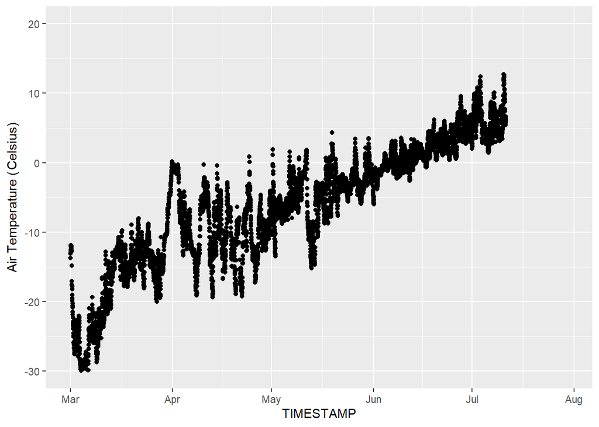

```r
ggplot(data = df)+
  geom_point(aes(TIMESTAMP,AirTC_Avg),col='black')+
  scale_y_continuous(limits = c(-30,20),
                     expression('Air Temperature ('*Celsius*')'))+
  scale_x_datetime(limits = as.POSIXct(biomet_dates,format="%F"))
```

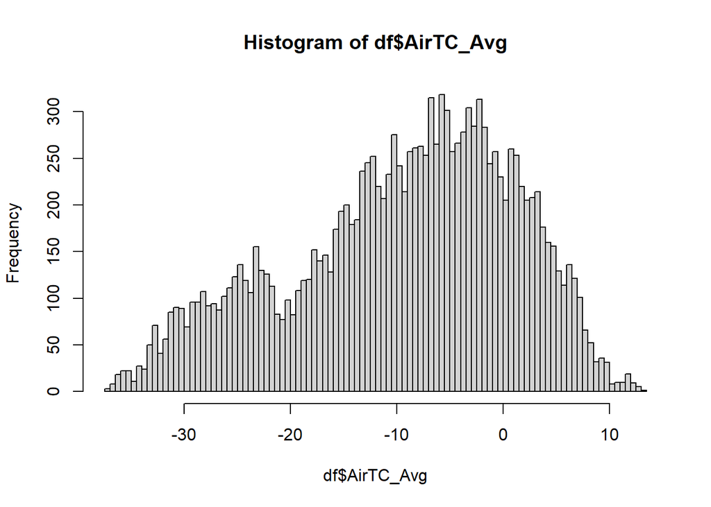

```r
hist(df$AirTC_Avg,breaks=100)
```

```r
AirTC.limits = df$AirTC_Avg
df$AirTC_Avg.c = AirTC.limits
```

#### Relative Humidity

Doesn’t clean anything right how- looks fine

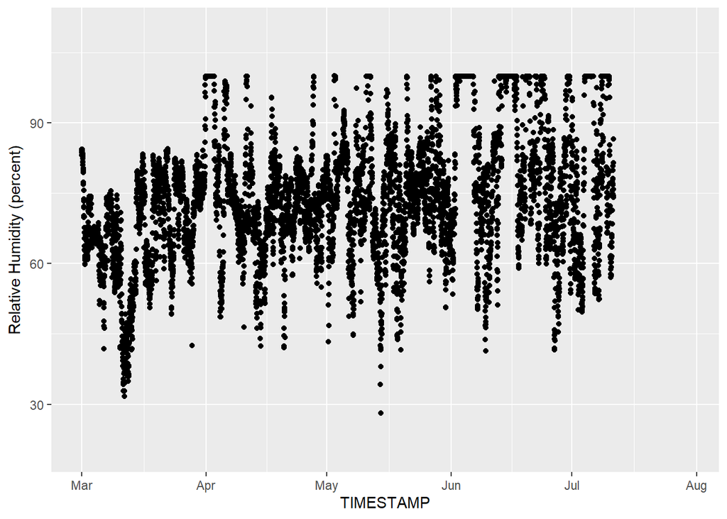

```r
ggplot(data = df)+
  geom_point(aes(TIMESTAMP,RH_Avg),col='black')+
  scale_y_continuous(limits = c(20,110),
                     expression('Relative Humidity ('*percent*')'))+
  scale_x_datetime(limits = as.POSIXct(biomet_dates,format="%F"))
```

```r
RH.limits = df$RH_Avg

df$RH_Avg.c = RH.limits
```

#### Soil Heat Flux

Plots all three values

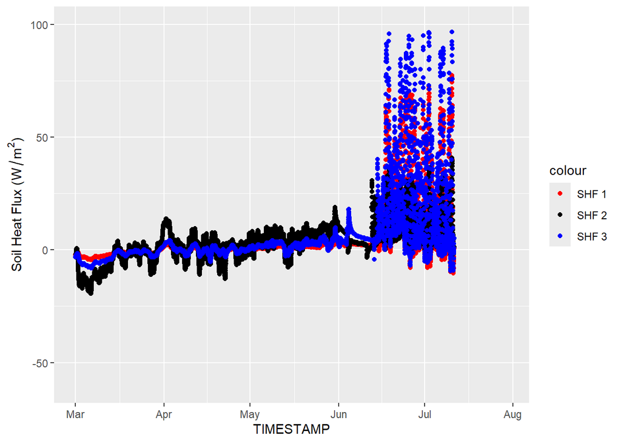

```r
ggplot(data = df)+
  geom_point(aes(TIMESTAMP,SHFP_Avg_1,col='SHF 1'))+
  geom_point(aes(TIMESTAMP,SHFP_Avg_2,col='SHF 2'))+
  geom_point(aes(TIMESTAMP,SHFP_Avg_3,col='SHF 3'))+
  scale_y_continuous(limits = c(-60,100),
                     expression ('Soil Heat Flux ('*W/m^2*')'))+
  scale_color_manual(values = c('red','black', 'blue'))+
  scale_x_datetime(limits = as.POSIXct(biomet_dates,format="%F"))
```

SHF1 - does nothing, looks fine

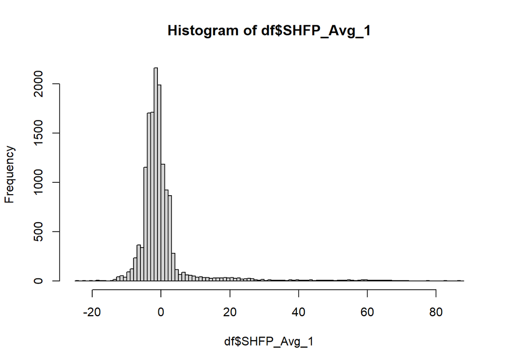

```r
hist(df$SHFP_Avg_1,breaks=100)
```

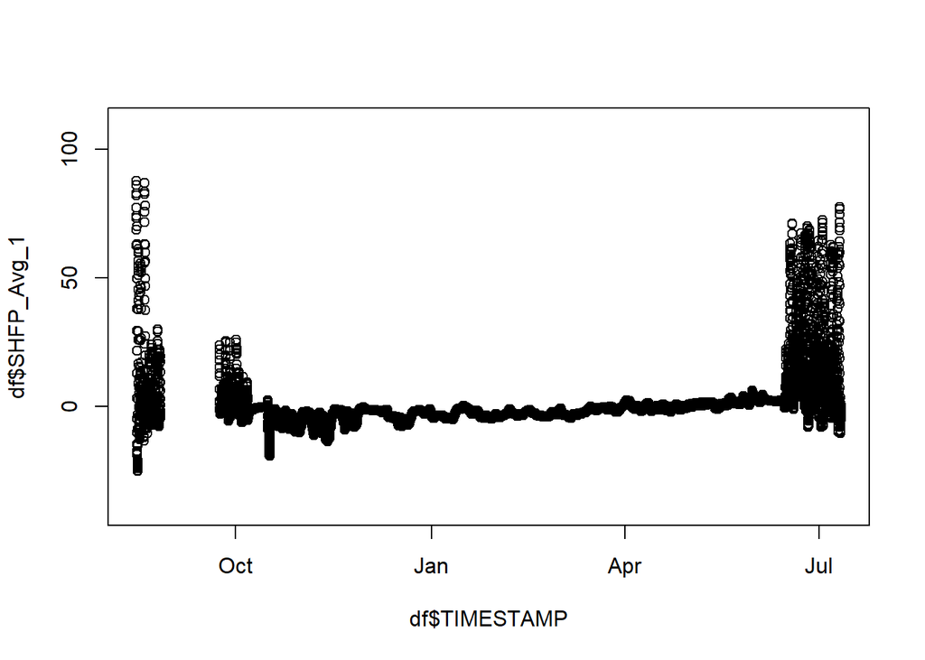

```r
plot(df$TIMESTAMP,df$SHFP_Avg_1,ylim = c(-40,110))
```

```r
df$SHFP_Avg_1.c = df$SHFP_Avg_1
```

SHF2 - does nothing, looks fine

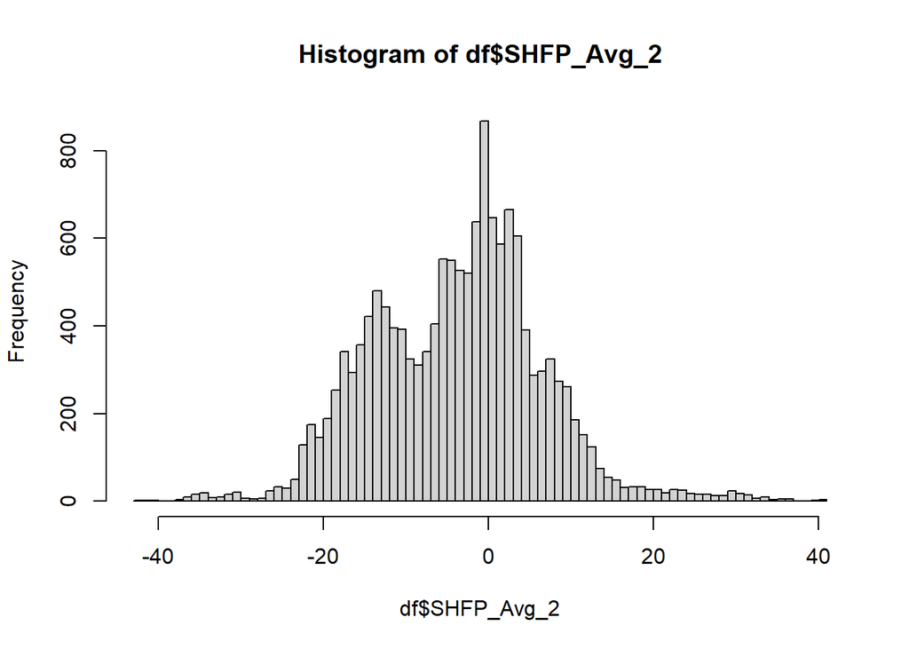

```r
hist(df$SHFP_Avg_2,breaks=100)
```

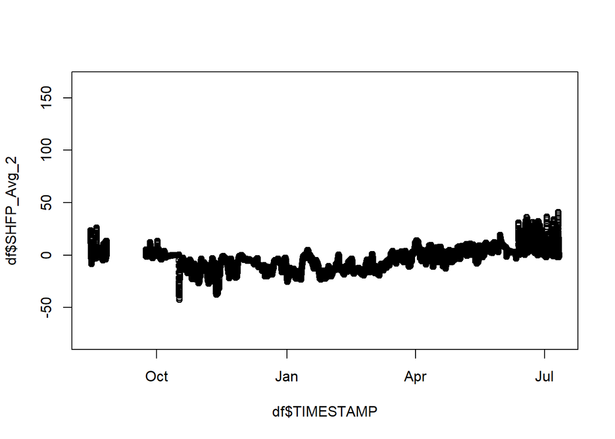

```r
plot(df$TIMESTAMP,df$SHFP_Avg_2,ylim = c(-80,165))
```

```r
df$SHFP_Avg_2.c = df$SHFP_Avg_2
```

SHF3 - does nothing, looks fine

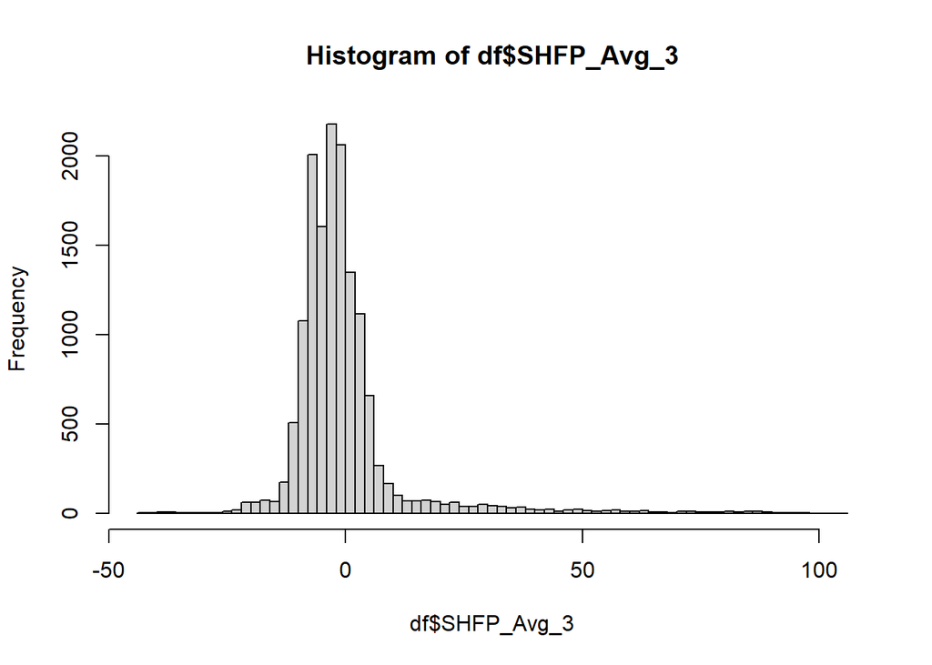

```r
hist(df$SHFP_Avg_3,breaks=100)
```

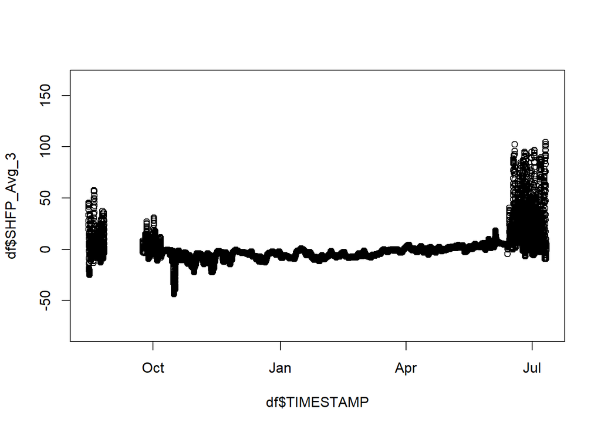

```r
plot(df$TIMESTAMP,df$SHFP_Avg_3,ylim = c(-80,165))
```

```r
df$SHFP_Avg_3.c = df$SHFP_Avg_3
```

#### PAR in

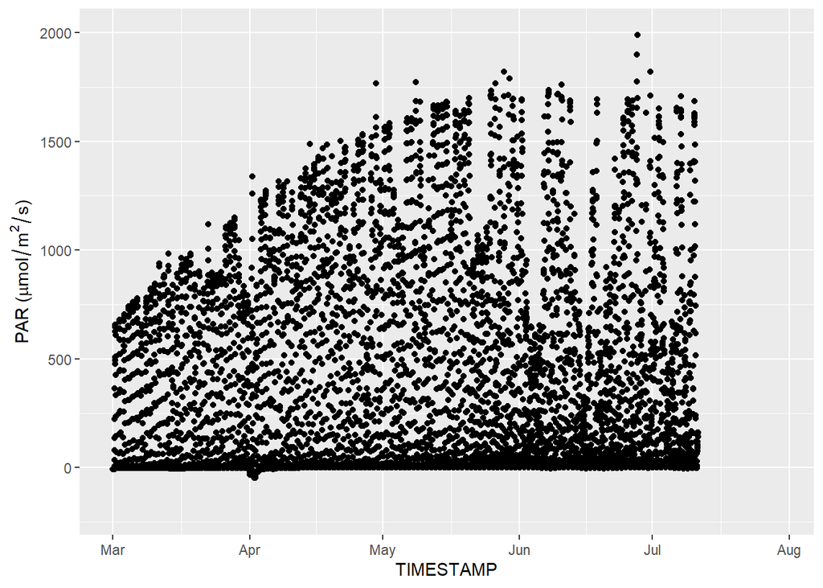

```r
ggplot(data = df)+
  geom_point(aes(TIMESTAMP,PPFDu_Avg),col='black')+
  scale_y_continuous(limits = c(-200, 2000),
                     expression('PAR ('*mu*mol/m^2/s*')'))+
  scale_x_datetime(limits = as.POSIXct(biomet_dates,format="%F"))
```

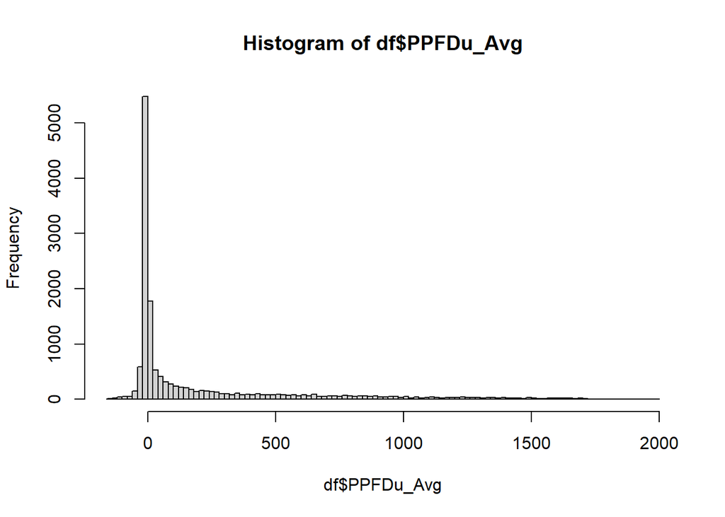

```r
hist(df$PPFDu_Avg,breaks=100)
```

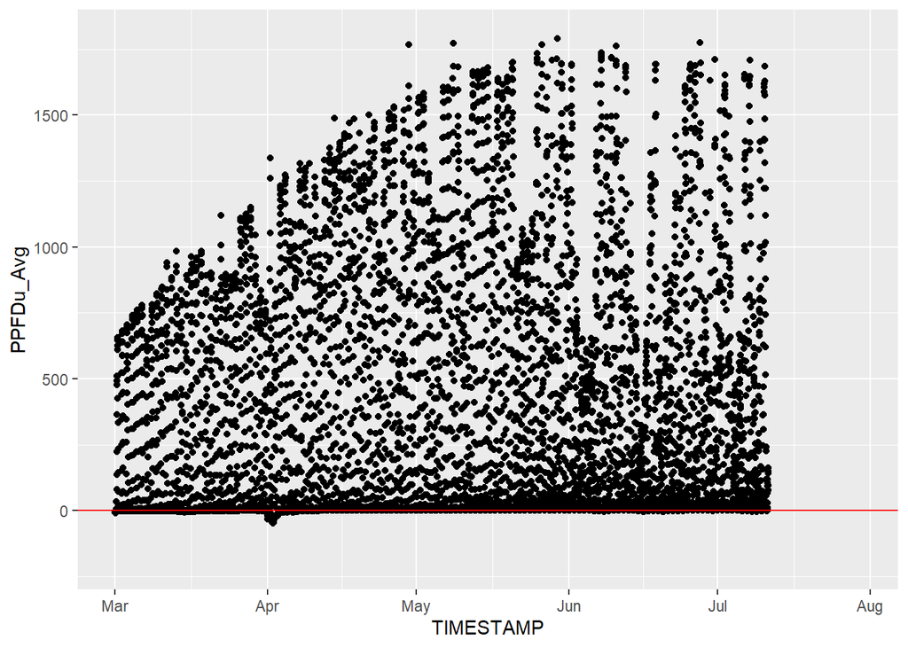

```r
ggplot(data = df)+geom_hline(yintercept = 0)+
  geom_point(aes(x=TIMESTAMP,y=PPFDu_Avg))+
  geom_hline(yintercept = 0, col="red")+
  scale_y_continuous(limits = c(-200, 1800))+
  scale_x_datetime(limits = as.POSIXct(biomet_dates,format="%F"))
```

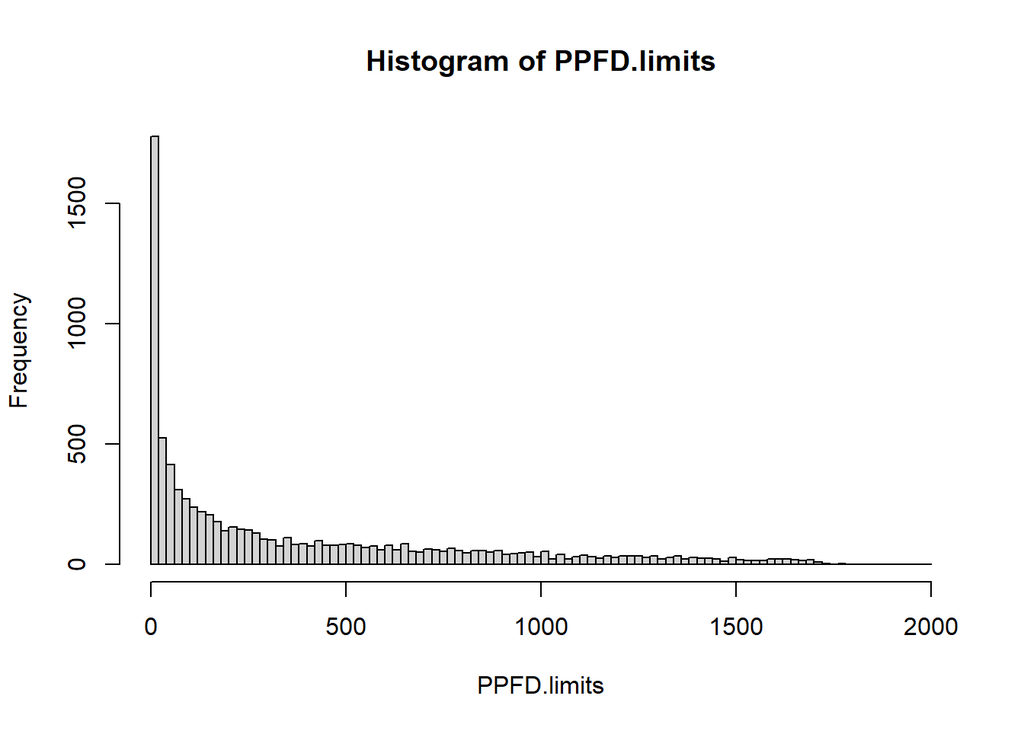

```r
PPFD.limits = replace(df$PPFDu_Avg, df$PPFDu_Avg < 0,NA)


hist(PPFD.limits,breaks=100)
```

Rolling SD

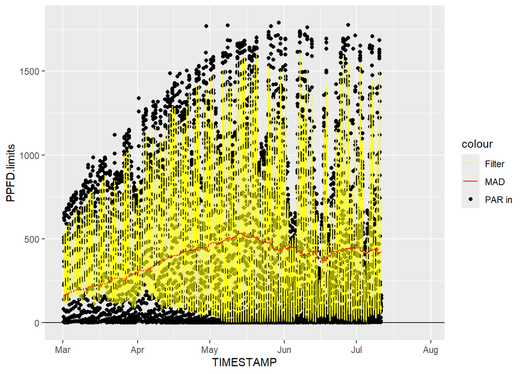

```r
f = PPFD.limits # first make a new flux vector to apply the above filters
# prepare the inputs for a zero-phase (forward and reverse) filter
ind       = which(complete.cases(f))   # first save the index of all the NAs
b         = rep(1,8)/8                 # moving average coefficient
a         = 1                          # coefficient of the ARMA filter
mad_i    = filtfilt(b, a, na.omit(f)) # create a forward and reverse ARMA filter
mad_filt = f                          # make a copy of the full fluxes again
mad_filt[ind] = mad_i                # apply the filter where the real data exist

n = 14*48 # set the length of the rolling filter, 48 half hours in day * x days
roll.mad = rollapply(data = mad_filt,
                     width = n,
                     FUN = sd,
                     partial = TRUE,
                     na.rm = T,
                     fill = NA)  #create a rolling MAD or sd or other
roll.mad[is.na(mad_filt)] = NA  #make NA values where NAs exist in the real data

ggplot(df)+geom_hline(yintercept = 0)+
  geom_point(aes(TIMESTAMP,PPFD.limits,col='PAR in'))+
  geom_line(aes(TIMESTAMP,mad_filt,col='Filter'))+
  geom_line(aes(TIMESTAMP,roll.mad,col='MAD'))+
  scale_y_continuous(limits = c(-15,1800))+
  scale_x_datetime(limits = as.POSIXct(biomet_dates,format="%F"))+
  scale_color_manual(values=c('yellow','red','black'))
```

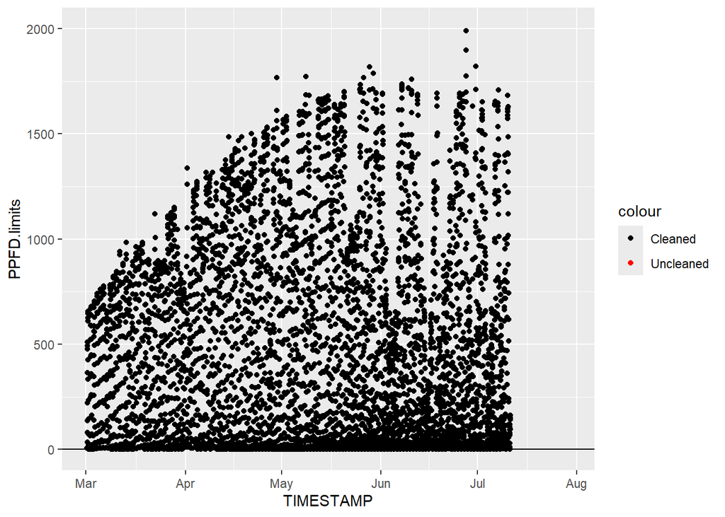

```r
#adjust this value (N) to tweak how many MADs to be away from the norm (4 default)
N = 4

#Add clean value to dataframe (_.c)

df$PPFDu_Avg.c = ifelse(abs(PPFD.limits - mad_filt) > (N * roll.mad),NA,PPFD.limits)

#Compare cleaned vs. uncleaned

ggplot(df)+geom_hline(yintercept = 0)+
  geom_point(aes(TIMESTAMP,PPFD.limits,col='Uncleaned'))+
  geom_point(aes(TIMESTAMP,PPFDu_Avg.c,col='Cleaned'))+
  scale_y_continuous(limits = c(0,2000))+
  scale_x_datetime(limits = as.POSIXct(biomet_dates,format="%F"))+
  scale_color_manual(values=c('black','red'))
```

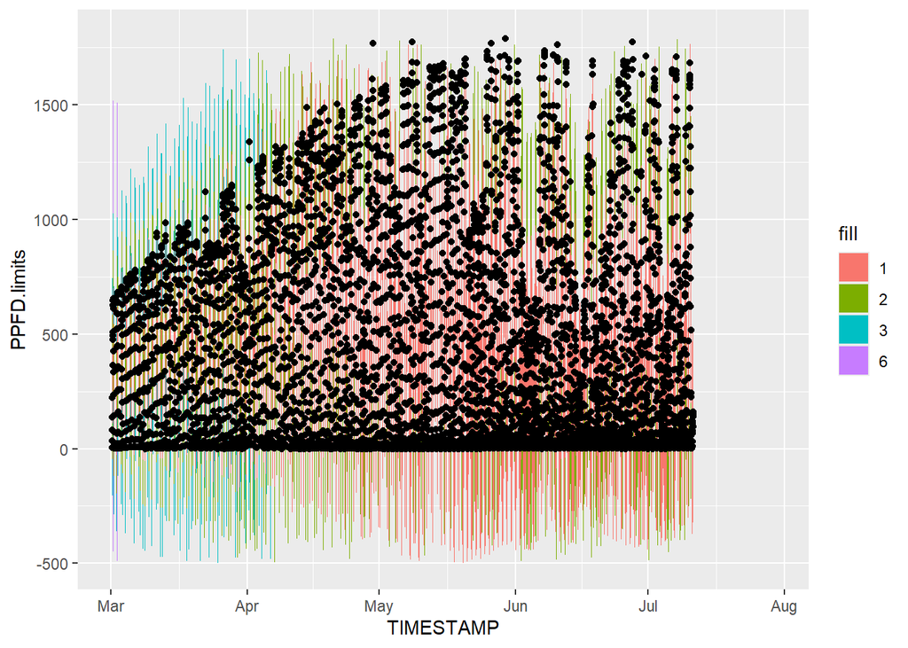

```r
# plot range of different N vals

ggplot(data = df)+
  geom_ribbon(aes(x = TIMESTAMP,ymax = mad_filt+roll.mad*6,ymin = mad_filt-roll.mad*6,fill='6'))+
  geom_ribbon(aes(x = TIMESTAMP,ymax = mad_filt+roll.mad*3,ymin = mad_filt-roll.mad*3,fill='3'))+
  geom_ribbon(aes(x = TIMESTAMP,ymax = mad_filt+roll.mad*2,ymin = mad_filt-roll.mad*2,fill='2'))+
  geom_ribbon(aes(x = TIMESTAMP,ymax = mad_filt+roll.mad*1,ymin = mad_filt-roll.mad*1,fill='1'))+
  geom_point(aes(TIMESTAMP,PPFD.limits),col='red')+
  geom_point(aes(TIMESTAMP,PPFDu_Avg.c),col='black')+
  scale_y_continuous(limits = c(-500,1800))+
  scale_x_datetime(limits = as.POSIXct(biomet_dates,format="%F"))
```

#### Net Radiation

No initial cleaning- looks fine

[figure not shown]

Rolling SD

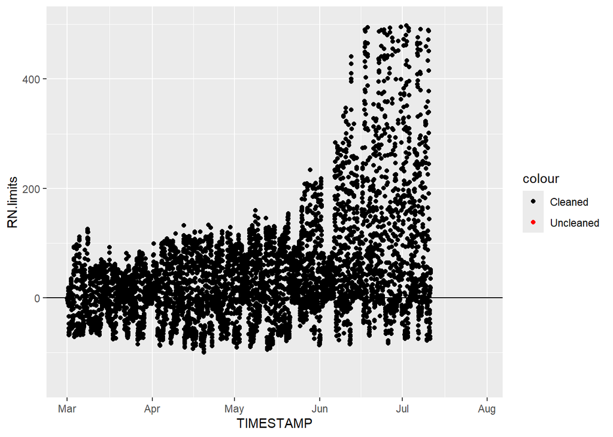

```r
f = RN.limits # first make a new flux vector to apply the above filters
# prepare the inputs for a zero-phase (forward and reverse) filter
ind       = which(complete.cases(f))   # first save the index of all the NAs
b         = rep(1,8)/8                 # moving average coefficient
a         = 1                          # coefficient of the ARMA filter
mad_i    = filtfilt(b, a, na.omit(f)) #create a forward and reverse ARMA filter
mad_filt = f                          # make a copy of the full fluxes again
mad_filt[ind] = mad_i                # apply the filter where the real data exist

n = 7*48 # set the length of the rolling filter, 48 half hours in day * x days
roll.mad = rollapply(data = mad_filt,
                     width = n,
                     FUN = sd,
                     partial = TRUE,
                     na.rm = T,
                     fill = NA)  #create a rolling MAD or sd or other
roll.mad[is.na(mad_filt)] = NA  #make NA values where NAs exist in the real data




#adjust this value (N) to tweak how many MADs to be away from the norm
N = 3

#Add clean value to dataframe (_.c)  (change these lines for new site)

df$Rn_Avg.c = ifelse(abs(RN.limits - mad_filt) > (N * roll.mad),NA,RN.limits)


#Compare cleaned vs. uncleaned

ggplot(df)+geom_hline(yintercept = 0)+
  geom_point(aes(TIMESTAMP,RN.limits,col='Uncleaned'))+
  geom_point(aes(TIMESTAMP,Rn_Avg.c,col='Cleaned'))+
  scale_y_continuous(limits = c(-150,500))+
  scale_x_datetime(limits = as.POSIXct(biomet_dates,format="%F"))+
  scale_color_manual(values=c('black','red'))
```

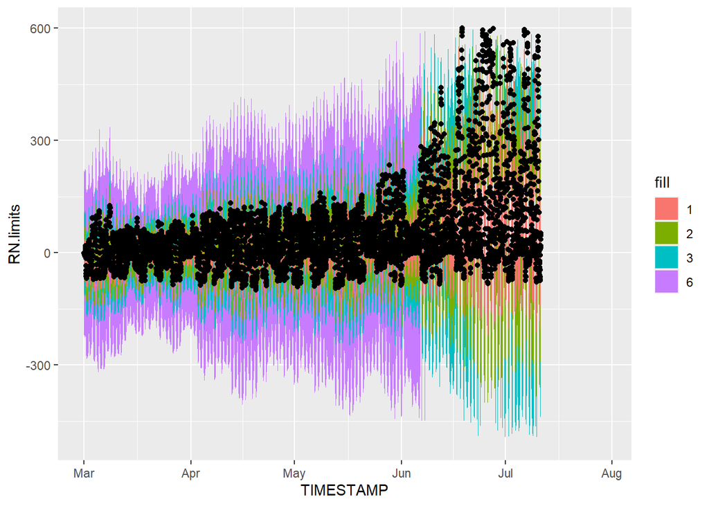

```r
ggplot(data = df)+
  geom_ribbon(aes(x = TIMESTAMP,ymax = mad_filt+roll.mad*6,ymin = mad_filt-roll.mad*6,fill='6'))+
  geom_ribbon(aes(x = TIMESTAMP,ymax = mad_filt+roll.mad*3,ymin = mad_filt-roll.mad*3,fill='3'))+
  geom_ribbon(aes(x = TIMESTAMP,ymax = mad_filt+roll.mad*2,ymin = mad_filt-roll.mad*2,fill='2'))+
  geom_ribbon(aes(x = TIMESTAMP,ymax = mad_filt+roll.mad*1,ymin = mad_filt-roll.mad*1,fill='1'))+
  geom_point(aes(TIMESTAMP,RN.limits),col='red')+
  geom_point(aes(TIMESTAMP, Rn_Avg.c),col='black')+
  scale_y_continuous(limits = c(-500,600))+
  scale_x_datetime(limits = as.POSIXct(biomet_dates,format="%F"))
```

#### Shortwave Out (Energy going up)

Initial Cleaning with Limits

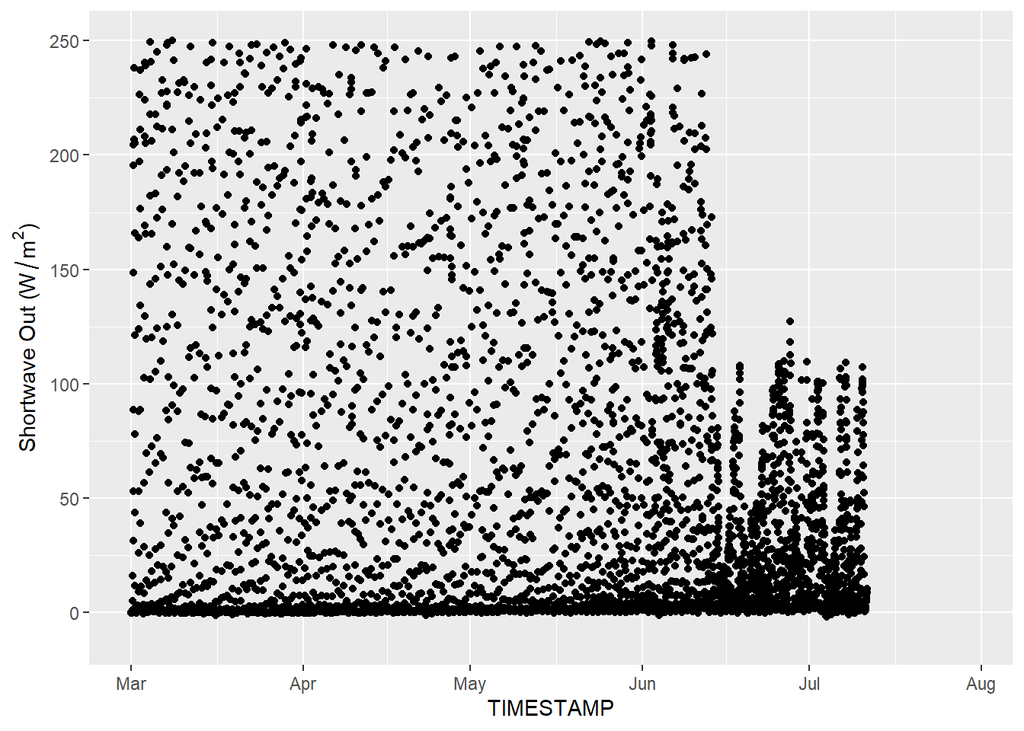

```r
ggplot(data = df)+
  geom_point(aes(TIMESTAMP,Su_Avg))+
  scale_y_continuous(limits = c(-10,250),
                     expression('Shortwave Out ('*W/m^2*')'))+
  scale_x_datetime(limits = as.POSIXct(biomet_dates,format="%F"))
```

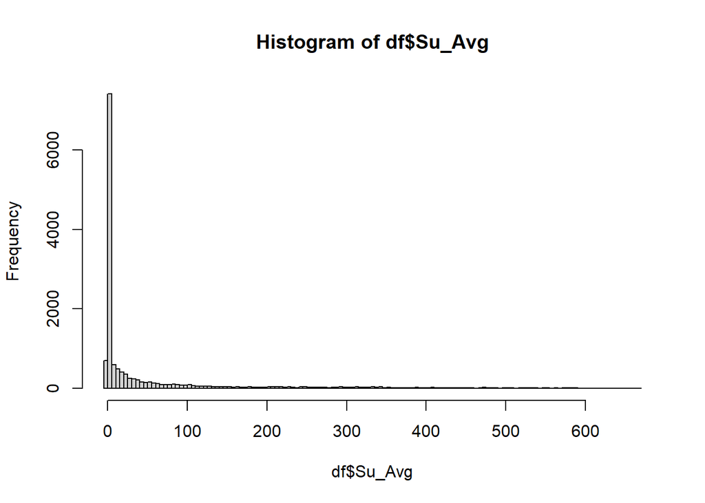

```r
hist(df$Su_Avg,breaks=100)
```

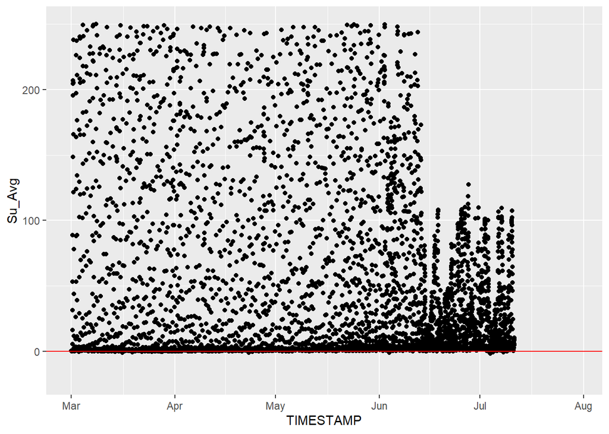

```r
ggplot(data = df)+geom_hline(yintercept = 0)+
  geom_point(aes(x=TIMESTAMP,y=Su_Avg))+
  geom_hline(yintercept = 0, col="red")+
  scale_y_continuous(limits = c(-20, 250))+
  scale_x_datetime(limits = as.POSIXct(biomet_dates,format="%F"))
```

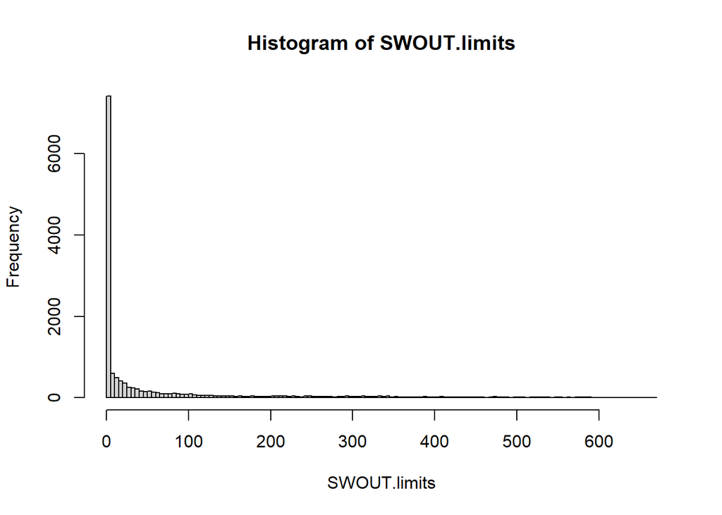

```r
SWOUT.limits = replace(df$Su_Avg, df$Su_Avg < 0,NA)


hist(SWOUT.limits,breaks=100)
```

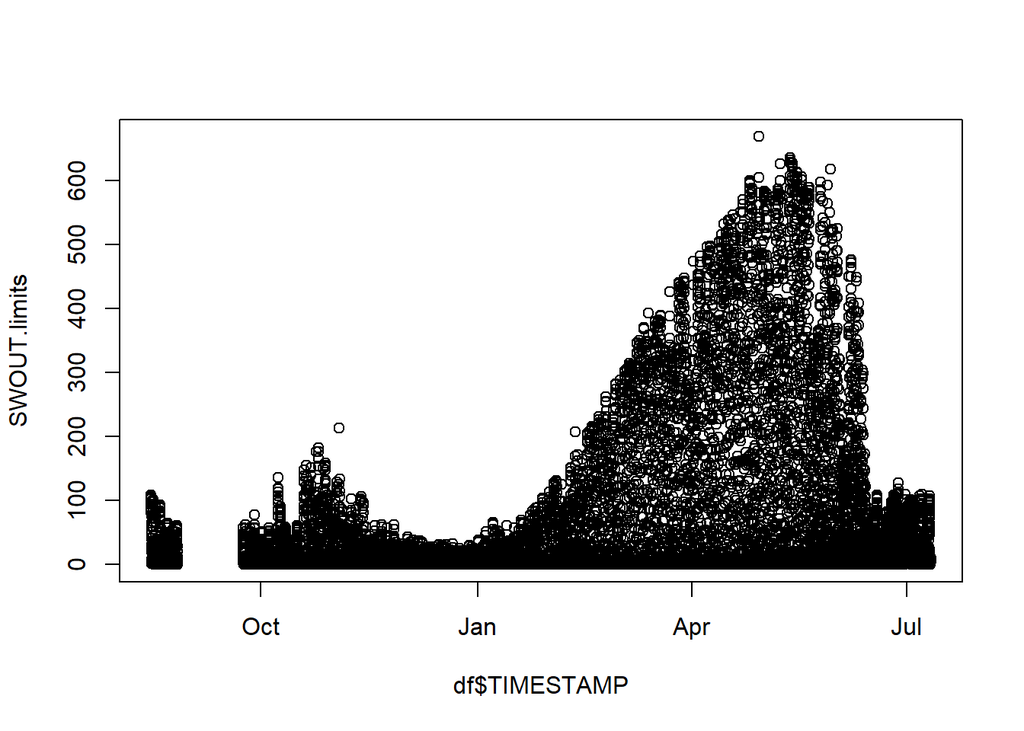

```r
plot(df$TIMESTAMP,SWOUT.limits)
```

Rolling SD

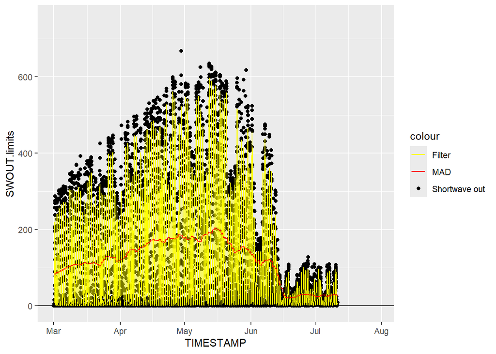

```r
f = SWOUT.limits # first make a new flux vector to apply the above filters
# prepare the inputs for a zero-phase (forward and reverse) filter
ind       = which(complete.cases(f))   # first save the index of all the NAs
b         = rep(1,8)/8                 # moving average coefficient
a         = 1                          # coefficient of the ARMA filter
mad_i    = filtfilt(b, a, na.omit(f)) #create a forward and reverse ARMA filter
mad_filt = f                          # make a copy of the full fluxes again
mad_filt[ind] = mad_i                # apply the filter where the real data exist

n = 7*48 # set the length of the rolling filter, 48 half hours in day * x days
roll.mad = rollapply(data = mad_filt,
                     width = n,
                     FUN = sd,
                     partial = TRUE,
                     na.rm = T,
                     fill = NA)  #create a rolling MAD or sd or other
roll.mad[is.na(mad_filt)] = NA  #make NA values where NAs exist in the real data


ggplot(df)+geom_hline(yintercept = 0)+
  geom_point(aes(TIMESTAMP,SWOUT.limits,col='Shortwave out'))+
  geom_line(aes(TIMESTAMP,mad_filt,col='Filter'))+
  geom_line(aes(TIMESTAMP,roll.mad,col='MAD'))+
  scale_y_continuous(limits = c(-5,750))+
  scale_x_datetime(limits = as.POSIXct(biomet_dates,format="%F"))+
  scale_color_manual(values=c('yellow','red','black'))
```

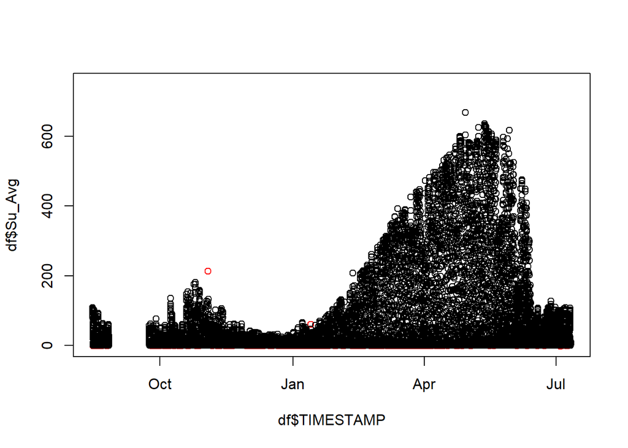

```r
#adjust this value (N) to tweak how many MADs to be away from the norm
N = 4

#Add clean value to dataframe (_.c)

df$Su_Avg.c = ifelse(abs(SWOUT.limits - mad_filt) > (N * roll.mad),NA,SWOUT.limits)


#Compare cleaned vs. uncleaned

plot(df$TIMESTAMP,df$Su_Avg,col='red',ylim = c(-1,750));points(df$TIMESTAMP,df$Su_Avg.c)
```

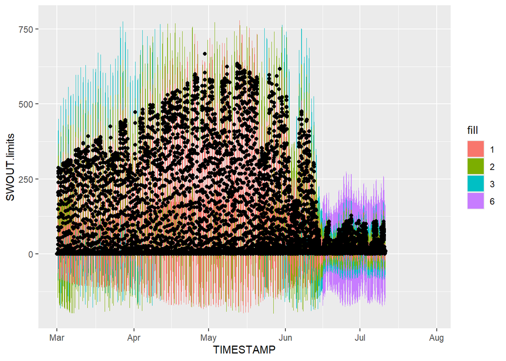

```r
ggplot(data = df)+
  geom_ribbon(aes(x = TIMESTAMP,ymax = mad_filt+roll.mad*6,ymin = mad_filt-roll.mad*6,fill='6'))+
  geom_ribbon(aes(x = TIMESTAMP,ymax = mad_filt+roll.mad*3,ymin = mad_filt-roll.mad*3,fill='3'))+
  geom_ribbon(aes(x = TIMESTAMP,ymax = mad_filt+roll.mad*2,ymin = mad_filt-roll.mad*2,fill='2'))+
  geom_ribbon(aes(x = TIMESTAMP,ymax = mad_filt+roll.mad*1,ymin = mad_filt-roll.mad*1,fill='1'))+
  geom_point(aes(TIMESTAMP,SWOUT.limits),col='red')+
  geom_point(aes(TIMESTAMP,Su_Avg.c),col='black')+
  scale_y_continuous(limits = c(-200,780))+
  scale_x_datetime(limits = as.POSIXct(biomet_dates,format="%F"))
```

#### Shortwave In (Energy going down)

Initial Cleaning with Limits

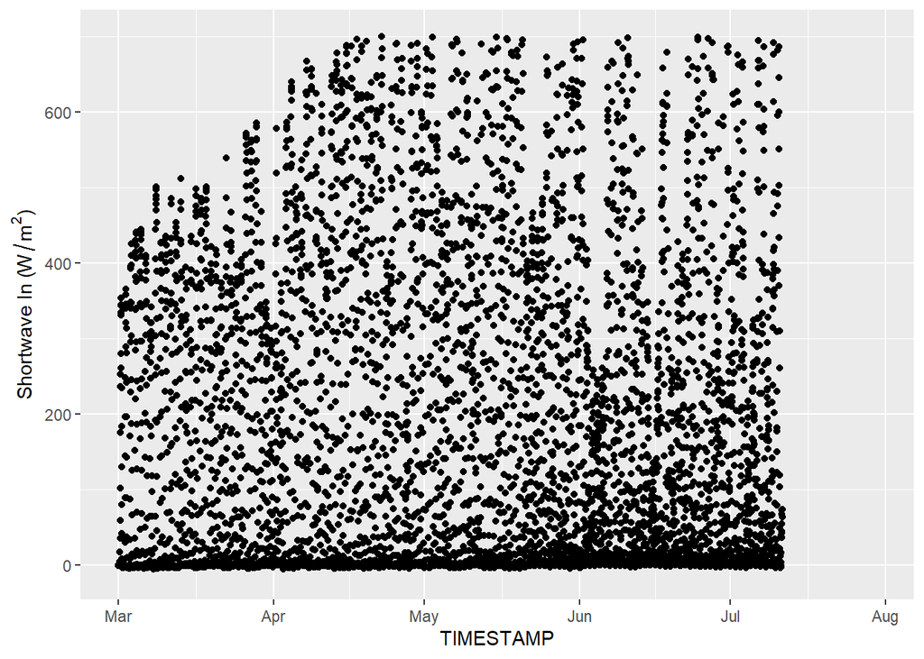

```r
ggplot(data = df)+
  geom_point(aes(TIMESTAMP,Sd_Avg))+
  scale_y_continuous(limits = c(-10,700),
                     expression('Shortwave In ('*W/m^2*')'))+
  scale_x_datetime(limits = as.POSIXct(biomet_dates,format="%F"))
```

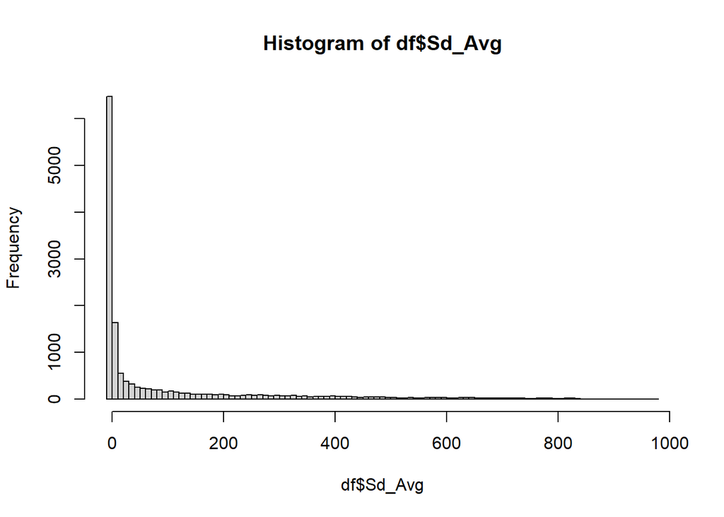

```r
hist(df$Sd_Avg,breaks=100)
```

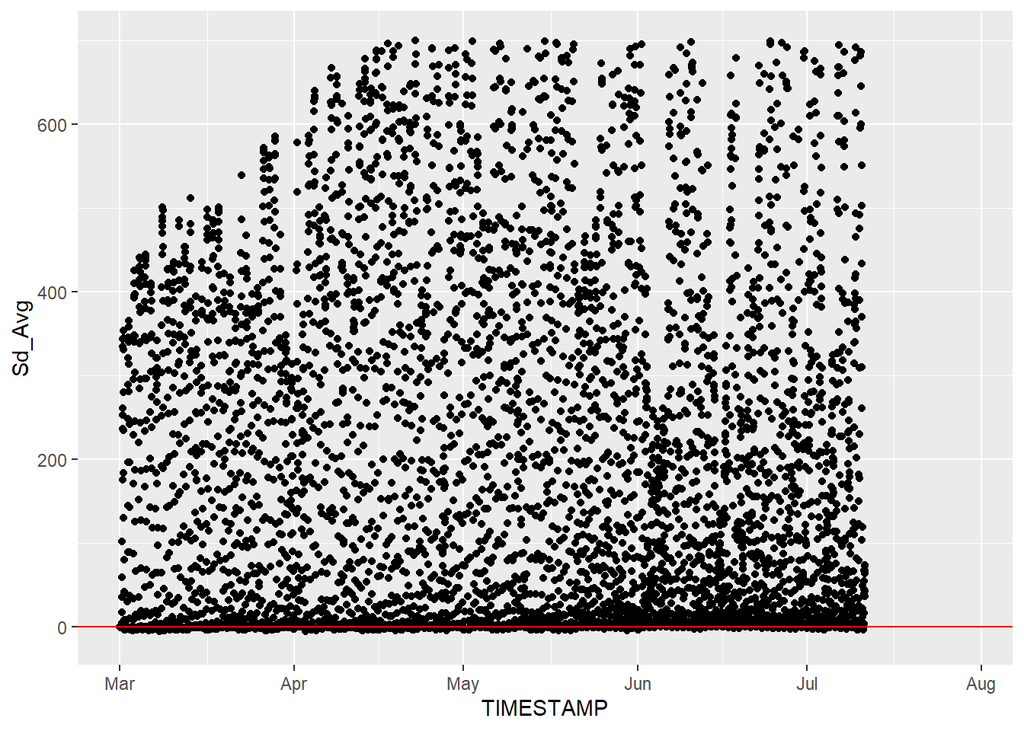

```r
ggplot(data = df)+geom_hline(yintercept = 0)+
  geom_point(aes(x=TIMESTAMP,y=Sd_Avg))+
  geom_hline(yintercept = 0, col="red")+
  scale_y_continuous(limits = c(-10, 700))+
  scale_x_datetime(limits = as.POSIXct(biomet_dates,format="%F"))
```

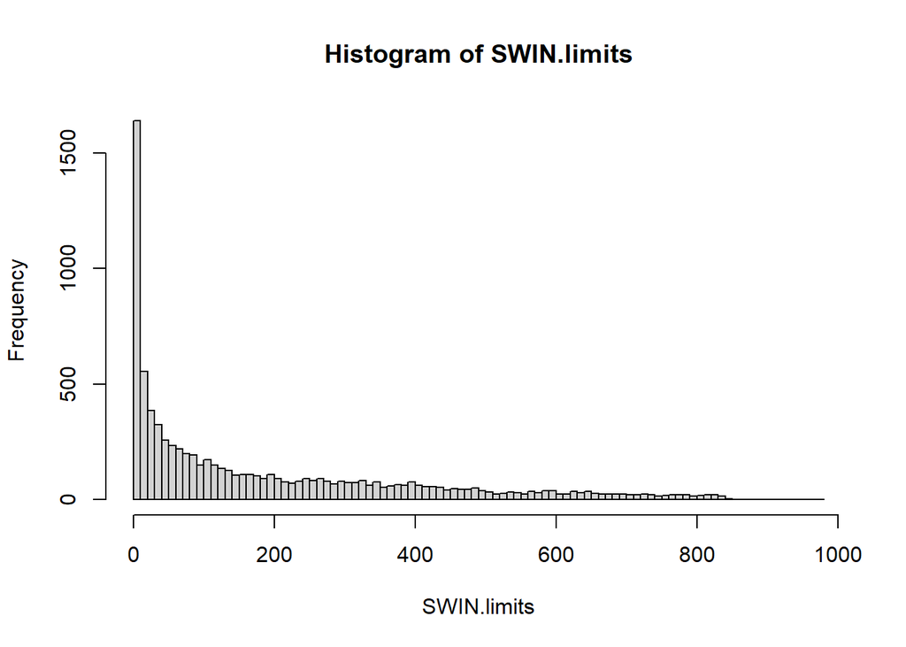

```r
SWIN.limits = replace(df$Sd_Avg, df$Sd_Avg < 0,NA)


hist(SWIN.limits,breaks=100)
```